# Multi-layer Perceptron

# Task - 1 - Rosenblatt’s perceptron

Before defining perceptrons, we will briefly define neural networks. At their most basic levels, neural networks have three layers: an input layer, a hidden layer, and an output layer. The input layer consists of all of the original input features. The majority of the learning takes place in the hidden layer, and the output layer outputs the final predictions.

A perceptron, also known as feedforward deep neural networks, is defined as a densely connected layers where inputs influence each successive layer which then influences the final output layer. When developing the network architecture for a perceptron, we only need to worry about two features: (1) layers and nodes, and (2) activation.

For predicting a binary output (e.g., True/False, Win/Loss), the output layer will still contain only one node and that node will predict the probability of success. However, if we are predicting a multinomial output, the output layer will contain the same number of nodes as the number of classes being predicted.

In the human brain, the biologic neuron receives inputs from many adjacent neurons. When these inputs accumulate beyond a certain threshold the neuron is activated suggesting there is a signal. DNNs work in a similar fashion. The activation function is simply a mathematical function that determines whether or not there is enough informative input at a node to fire a signal to the next layer. Rectified Linear unit (ReLU) is one of them. This function simply takes the summed weighted inputs and transforming them to a $0$ (not fire) or $>0$ (fire) if there is enough signal.

1. Plotting sepal length and sepal width of the two classes, setosa and versicolor, of the iris data set.

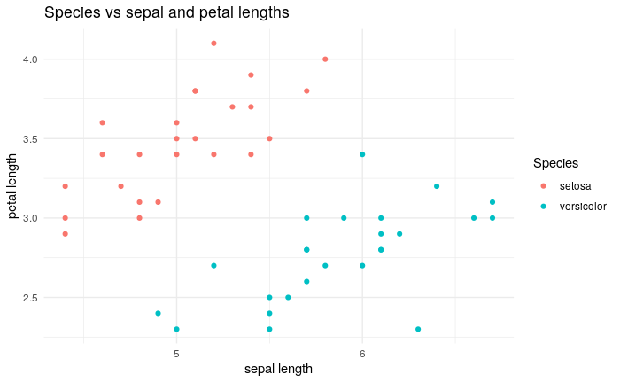

```r
#-- clear environment and load data
rm(list=ls())
library(ggplot2)
library(dplyr)
library(tidyverse)
df = iris
#-- load and visualize data using ggplot2
df = df[, c(1,2,5)]
df = df %>% filter(Species == c("setosa","versicolor"))
g = ggplot(data=df, aes(x=Sepal.Length, y=Sepal.Width, color = Species)) +
  geom_point() +
  theme_minimal() +
  xlab("sepal length") +
  ylab("petal length") +
  ggtitle("Species vs sepal and petal lengths")
g
```

The classes seem indeed linearly separable. This means that there must exists a hyperplane which separates the data points in way making all the points belonging positive class lie on one side of hyperplane and the data points belonging to negative class lie on the other side.

2. Write the algorithm of the original Rosenblatt’s perceptron to classify the above irises, Setosa or versicolor.

```r
#-- before programming the function, we need to encode the outcome variable to -1 and 1 and split data to x and y inputs
df[, 4] = 1
df[df[, 3] == "setosa", 4] = -1
x = df[,c(1,2)]
y = df[,4]
```

weight vector is the normal vector + an intercept (perpendicular to the hyperplance used to seperate the classes). The normal vector $\vec{w}^T = [b,w_1,w_2]^T$. We have two weights for the two variables; sepal length and sepal width. The classification rule then checks whether the data point lies on the positive side of the hyperplane or on the negative side, it does so by checking the dot product of the $\vec{w}$ with $\vec{x}_i$.

```r
#-- build training function
perceptron.train = function(x, y, eta, niter, normal_vector, intercept) {

        # build weight vector
        weight = c(intercept, normal_vector)
        errors = rep(0, niter)

        # loop over number of epochs niter
        for (j in 1:niter) {

                # loop through training data set
                for (i in 1:length(y)) {

                        # Predict binary label using Heaviside activation function
                        z = sum(weight[2:length(weight)]*as.numeric(x[i, ])) + weight[1]
                        if(z < 0) {
                                ypred = -1
                        } else {
                                ypred = 1
                        }

                        # Change weight - but don't do anything if the predicted value is correct
                        weightdiff = eta * (y[i] - ypred)*c(1, as.numeric(x[i, ]))
                        weight = weight + weightdiff

                        # Update error function
                        if ((y[i] - ypred) != 0.0) {
                                errors[j] = errors[j] + 1
                        }
                }
        }
        print(weight)

        # return weight to decide between the two species and the error
        return(list(errors = errors, normal_vector = weight[-1], intercept = weight[1]))
}
#-- build classification function
perceptron.classify = function(x_new, normal_vector, intercept){
  # build weight vector
  weight = c(intercept, normal_vector)
  y_pred = rep(0, dim(x_new)[1])

  #-- loop over the test data and make classification
  for (i in 1:dim(x_new)[1]) {

    # Predict binary label using Heaviside activation function
    z = sum(weight[2:length(weight)]*as.numeric(x_new[i, ])) + weight[1]
    if(z < 0) {
      y_pred[i] = -1
      }
    else {
      y_pred[i] = 1
    }
  }
  return(y_pred)
}
```

```r
#-- test train split and apply function
train_sample = sample(1: nrow(x), 0.8*nrow(x))
x_train = x[train_sample,]
y_train = y[train_sample]
x_test = x[-train_sample,]
y_test = y[-train_sample]
err = perceptron.train(x_train, y_train, 0.01, 20, c(0,0),0)
```

```
[1] -0.020  0.208 -0.360
```

```r
cat("training error is : ", err$errors, "\n")
```

```
training error is :  6 20 6 2 2 2 2 2 2 2 1 0 0 0 0 0 0 0 0 0
```

```r
#-- make prediction and calculate error. it should be zero because they are perfectly separable
source("functions_tutorial_2.R")
y_pred = perceptron.classify(x_test, err$normal_vector, err$intercept)
calc_class_err(y_test, y_pred)
```

```
[1] 0
```

3. Visualize training rule of the perceptron

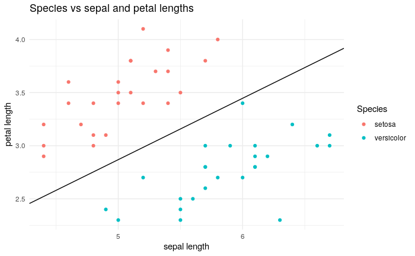

```r
#-- Visualize the classification rule as a segment (hyperplane separation). First we get the slope of the hyperplane as -dy/dx
a = -err$normal_vector[1]/err$normal_vector[2]
g + geom_abline(intercept = err$intercept, slope = a)
```

4. XOR data visualization

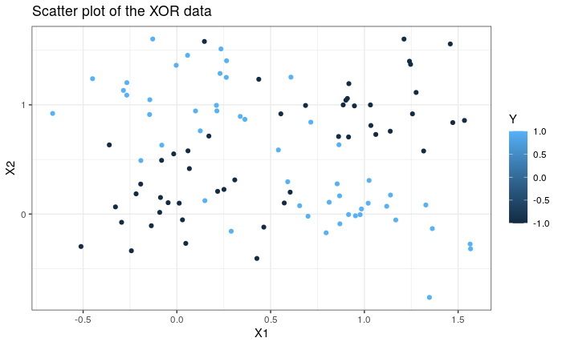

```r
#-- function to generate XOR data
gen_fuzzy_XOR = function(n, m1, m2, m3, m4, A) {
  library(MASS)
  d_1 = mvrnorm(n/4, m1, sqrt(A))
  d_2 = mvrnorm(n/4, m2, sqrt(A))
  d_3 = mvrnorm(n/4, m3, sqrt(A))
  d_4 = mvrnorm(n/4, m4, sqrt(A))

  df_class_0 = cbind(rbind(d_1,d_2), Y = -1)
  df_class_1 = cbind(rbind(d_3,d_4), Y = 1)

  df = as.data.frame(rbind(df_class_0, df_class_1))
  names(df)[1] = "X1"
  names(df)[2] = "X2"

  #-- Randomly shuffle
  rows = sample(nrow(df))
  df = df[rows,]
  row.names(df) = NULL
  return(df)
}
#-- generate and plot data
Q = matrix(c(0.01,0,0,0.01), nrow = 2, byrow = TRUE)
df = gen_fuzzy_XOR(100, c(0,0), c(1,1), c(0,1), c(1,0),Q)
#-- Visualize distributional setting of the data
g2 = ggplot(df, aes(x=X1, y=X2, col = Y)) + geom_point() + theme_bw() + ggtitle("Scatter plot of the XOR data")
g2
```

The data generated is not linearly separable.

5. build generalized perceptron

```r
perceptron.train.2 = function(df, int, n_vec){
  x = df[, c(1:2)]
  y = df[, 3]
  x_hat = cbind(x, x[,1]* x[,2], x[,1]**2, x[,2]**2)
  perceptron.train(x_hat, y, 0.01, 100, n_vec, int)
}
perceptron.classify.2 = function(df_test, int, n_vec){
  x_new = df_test[, c(1:2)]
  x_hat_new = cbind(x_new, x_new[,1]* x_new[,2], x_new[,1]**2, x_new[,2]**2)
  perceptron.classify(x_hat_new, normal_vector = n_vec, intercept = int)
}
#-- do a test train split and calculate error of perceptron
set.seed(1)
train_index = sample(1:nrow(df), 0.5*nrow(df))
df_train = df[train_index,]
df_test = df[-train_index,]
train = perceptron.train.2(df_train, 0, rep(0,5))
```

```
[1] -0.02000000  0.03338157  0.11109825 -0.16754181  0.03848697 -0.02372931
```

```r
y_pred = perceptron.classify.2(df_test, n_vec =  train$normal_vector, int = train$intercept)
error = calc_class_err(df_test$Y, y_pred)
error
```

```
[1] 0.16
```

6. Visualize classification rule

```r
#-- create a grid
mins <- c(min(df_train[,1]), min(df_train[,2]))
maxs <- c(max(df_train[,1]), max(df_train[,2]))
perStretch <- 0.04
mins[1] <- mins[1] - perStretch * (maxs[1] - mins[1])
mins[2] <- mins[2] - perStretch * (maxs[2] - mins[2])
maxs[1] <- maxs[1] + perStretch * (maxs[1] - mins[1])
maxs[2] <- maxs[2] + perStretch * (maxs[2] - mins[2])
#-- Expand the grid
frequency <- 100
gx <- seq(mins[1], maxs[1], length=frequency)
gy <- seq(mins[2], maxs[2], length=frequency)
Xgrid <- matrix(as.numeric(as.matrix(expand.grid(gx, gy))), ncol =2)
#-- make predictions
head(Xgrid)
```

```
           [,1]       [,2]
[1,] -0.7517374 -0.4860396
[2,] -0.7274085 -0.4860396
[3,] -0.7030797 -0.4860396
[4,] -0.6787509 -0.4860396
[5,] -0.6544220 -0.4860396
[6,] -0.6300932 -0.4860396
```

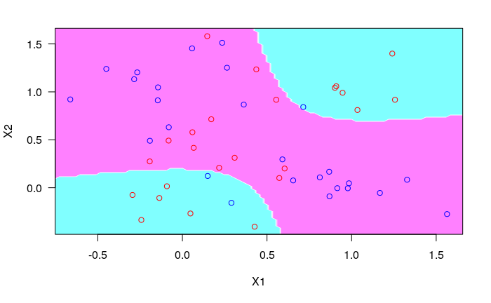

```r
yPredGrid = perceptron.classify.2(Xgrid,
                                  n_vec = train$normal_vector,
                                  int = train$intercept)
#-- plot
source("filledContour2.R")
filled.contour2(gx, gy,
                matrix(yPredGrid, nrow=length(gx), ncol=length(gy), byrow=FALSE),
                levels=c(-1.2,-1:5/5,1.2),
                xlab = "X1", ylab = "X2",
                xlim = c(mins[1], maxs[1]), ylim = c(mins[2], maxs[2]))
points(df_train[,1:2], col = c("red", "blue")[df_train[,3] / 2 + 1.5])
```

# Task - 2 - Classification with a multilayer perceptron

1. Generate 200 data points and visualize data from distributional setting 1 of tutorial 1

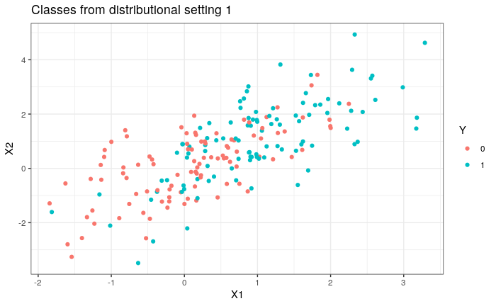

```r
set.seed(1)
Q = matrix(c(1,1,1,4), nrow = 2, byrow = TRUE)
df = gen_bin_data(200,c(0,0), c(1,1), Q, Q)
ggplot(df, aes(x=X1, y=X2, col = Y)) + geom_point() + theme_bw() +ggtitle("Classes from distributional setting 1")
```

```r
head(df)
```

|  | X1 | X2 | Y |
| --- | --- | --- | --- |
| 1 | 0.8830748 | 0.5859492 | 1 |
| 2 | 0.9965002 | 1.7180618 | 1 |
| 3 | 0.1343476 | 1.9391047 | 0 |
| 4 | 0.5984308 | 0.7598169 | 0 |
| 5 | 1.3057756 | 1.6112291 | 1 |
| 6 | -1.0149885 | -2.1088412 | 1 |

Previously in lab 2, we tested multiple classifiers. The best ones were LDA and random forests with errors of about 30%. This error is due to the fact that these classes are not lienarly separable.

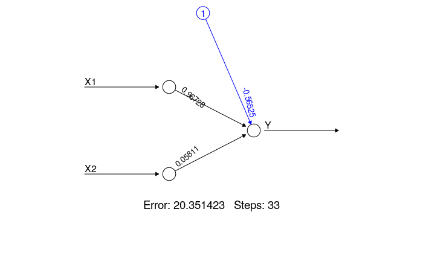

```r
#-- build and train a single neuron neural network (no hidden neurons, just input observations and output)
library(neuralnet)
df$Y = as.numeric(df$Y)-1
nn = neuralnet(Y~., data = df,
               hidden = 0,
               learningrate = 0.01,
               linear.output = FALSE,
               act.fct = "logistic")
#-- plot the neural network's architecture and visualize the result matrix that contains the weight vectors and the intercept.
plot(nn)
```

```r
nn$result.matrix
```

```
                          [,1]
error             20.351423179
reached.threshold  0.007744087
steps             33.000000000
Intercept.to.Y    -0.565251311
X1.to.Y            0.967276028
X2.to.Y            0.058113682
```

The above plot shows the input neurons (X1 and X2) and no hidden layers as described in the lab. The black lines show the connections with weights which are calculated using the back propagation algorithm. The blue line is the displays the bias term. Then the output is one neuron which yeilds predictions (1 and 0).

```r
#-- Making a prediction in neural networks and check accuracy
Y_pred = compute(nn, df[,c(1:2)])
Y_pred = round(as.numeric(Y_pred$net.result))
head(Y_pred)
```

```
[1] 1 1 0 1 1 0
```

```r
calc_class_err(df$Y, Y_pred)
```

```
[1] 0.3
```

The error, as we saw from previous parts in the labs, is still around 30%. This is due to the fact that the classifier in a single neuron neural network still considers a linear classification rule in the original space of the data (i.e. in two dimensions). I did not perform a test train split for this part. The error computed is the training error.

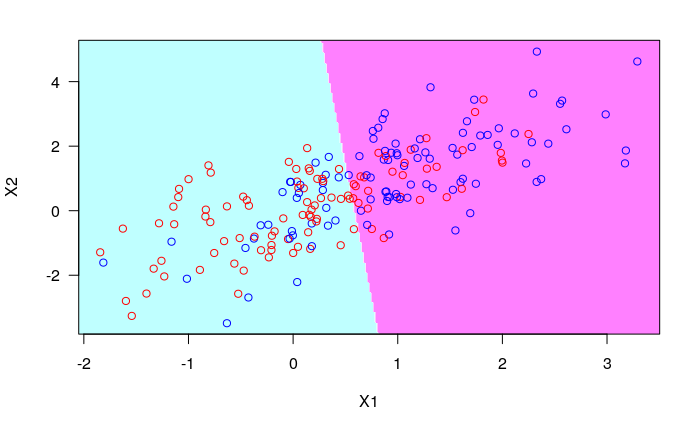

```r
#-- Visualize the prediction rule of the neural network
mins <- c(min(df[,1]), min(df[,2]))
maxs <- c(max(df[,1]), max(df[,2]))
perStretch <- 0.04
mins[1] <- mins[1] - perStretch * (maxs[1] - mins[1])
mins[2] <- mins[2] - perStretch * (maxs[2] - mins[2])
maxs[1] <- maxs[1] + perStretch * (maxs[1] - mins[1])
maxs[2] <- maxs[2] + perStretch * (maxs[2] - mins[2])
#-- Expand the grid
frequency <- 300
gx <- seq(mins[1], maxs[1], length=frequency)
gy <- seq(mins[2], maxs[2], length=frequency)
Xgrid <- matrix(as.numeric(as.matrix(expand.grid(gx, gy))), ncol =2)
#-- make predictions
yPredGrid = round(as.numeric(compute(nn, Xgrid)$net.result))

#-- plot
filled.contour2(gx, gy,
                matrix(yPredGrid, nrow=length(gx), ncol=length(gy), byrow=FALSE),
                levels=c(-1.2,-1:5/5,1.2),
                xlab = "X1", ylab = "X2",
                xlim = c(mins[1], maxs[1]), ylim = c(mins[2], maxs[2]))
points(df[,1:2], col = c("red", "blue")[df[,3] / 2 + 1.5])
```

The above plot confirms that the classification rule is linear.

2. Comparing with LDA

```r
#-- build lda model and make predictions. calculate error for the training set.
library(MASS)
model.lda = lda(Y~., data = df)
Y_pred.lda = predict(model.lda, df)$class
calc_class_err(df$Y, Y_pred.lda)
```

```
[1] 0.31
```

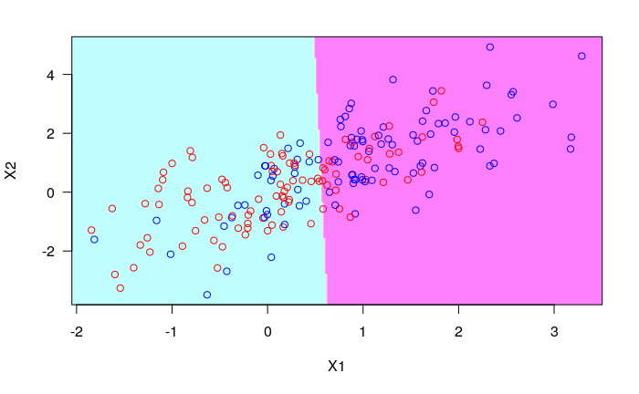

```r
#-- create a grid
mins <- c(min(df[,1]), min(df[,2]))
maxs <- c(max(df[,1]), max(df[,2]))
perStretch <- 0.04
mins[1] <- mins[1] - perStretch * (maxs[1] - mins[1])
mins[2] <- mins[2] - perStretch * (maxs[2] - mins[2])
maxs[1] <- maxs[1] + perStretch * (maxs[1] - mins[1])
maxs[2] <- maxs[2] + perStretch * (maxs[2] - mins[2])
#-- Expand the grid
frequency <- 300
gx <- seq(mins[1], maxs[1], length=frequency)
gy <- seq(mins[2], maxs[2], length=frequency)
Xgrid <- as.data.frame(matrix(as.numeric(as.matrix(expand.grid(gx, gy))), ncol =2))
names(Xgrid)[1] = "X1"
names(Xgrid)[2] = "X2"
#-- make predictions
yPredGrid = predict(model.lda, Xgrid)$class
#-- plot
source("filledContour2.R")
filled.contour2(gx, gy,
                matrix(yPredGrid, nrow=length(gx), ncol=length(gy), byrow=FALSE),
                levels=c(-1.2,-1:5/5,1.2),
                xlab = "X1", ylab = "X2",
                xlim = c(mins[1], maxs[1]), ylim = c(mins[2], maxs[2]))
points(df[,1:2], col = c("red", "blue")[df[,3] / 2 + 1.5])
```

Now we can compare the normal vectors of the seperating lines of both the neural network and the LDA algorithm by computing the dot product and calculating the angle

```r
#-- get normal vector for lda
a = as.vector(c(model.lda[[4]][1], model.lda[[4]][2]))
#-- get normal vector for nn
b = as.vector(c(nn$result.matrix[5,1],nn$result.matrix[6,1]))
names(normal.vec.nn) = NULL
#-- print values
cat("\n Normal vector of LDA \n", a)
```

```
 Normal vector of LDA
 1.042995 0.0158144
```

```r
cat("\n Normal vector of Neural Network \n", b)
```

```
 Normal vector of Neural Network
 0.967276 0.05811368
```

```r
#-- compute angle : (dot product of a and b gives norm a * norm b * cos (a,b)). The angle with this formula is expressed in radians.
theta = acos(sum(a*b)/(sqrt(sum(a*a))*sqrt(sum(b*b))))
cat("\n The angle between the two normal vectors of LDA and NN is \n", theta*180/pi)
```

```
 The angle between the two normal vectors of LDA and NN is
 2.569502
```

We can clearly see that the classification rule of LDA and a single neuron neural network is quite similar (almost the same in fact). This is proven through computing the training errors and the angle between the linear classification rules. Both are indeed very similar.